# Coursera Data Science Capstone Peer-Reviewed Assignment Week 2

Ali Pourkhesalian

11/11/2019

## Coursera Data Science Capstone (Week 2)

The presented document shows some data exploratroy analysis on the text data that can be downloaded from [here](https://d396qusza40orc.cloudfront.net/dsscapstone/dataset/Coursera-SwiftKey.zip). The main objective of this assignment is to make the sample corpus, build the 2-gram and 3-gram TDM and carry out exploratory analysis on the corpus.

## Preparation

The following packages are required:

```r
library(NLP)
library(ggplot2)
library(tm)
library(textmineR)
library(wordcloud)
library(stringr)
library(RWeka)
library(SnowballC)
library(data.table)
```

Reading text files:

```r
dataBlogEn <- readLines("en_US.blogs.txt", encoding = "UTF-8", skipNul = TRUE)
dataNewsEn <- readLines("en_US.news.txt", encoding = "UTF-8", skipNul = TRUE)
dataTwitterEn <- readLines("en_US.twitter.txt", encoding = "UTF-8", skipNul = TRUE)
```

## Basic Exploratory Analysis:

Nummber of English blog lines: 899288.  
Nummber of English news lines: 77259.  
Nummber of English Twitter lines: 2360148.  
Nummber of words in English blog: 37873860.  
Nummber of words in English News: 2662070.  
Nummber of words in English Twitter: 30555611.

## Sampling

Now, because the files are too big to be handled by my computer, 2000 lines of each file are sampled and binded and used in the report.

```r
sampleBlog <- readLines("en_US.blogs.txt", 2000)
sampleNews <- readLines("en_US.news.txt", 2000)
sampleTwitter <- readLines("en_US.Twitter.txt", 2000)
bindData <- c(sampleBlog, sampleNews, sampleTwitter)
```

## Tidying Up the Text

All numbers and non-word letters, punctuations, extra spaces and stop words are removed from the text and uppercase letters are lowercased.

```r
#Removing all non word and number characters
bindData <- gsub('\\W', ' ', bindData)
#Removing all numbers
bindData <- gsub('\\d', ' ', bindData)
#Conveting all letters into lowercase
bindData <- tolower(bindData)
#Removing stop words
bindData <- removeWords(bindData, stopwords(kind = "en"))
#removing all one-letter words
bindData <- gsub("\\b\\w\\b", " ", bindData)
#removing all empty spaces
bindData <- gsub("\\s{2,}", " ", bindData)
```

## Corpus

The cleaned text is turned into a corpus:

```r
dataCorpus <- Corpus(VectorSource(bindData))
```

## N-Gram Tokenization

Unigram, bigram and trigram are built using RWeka package:

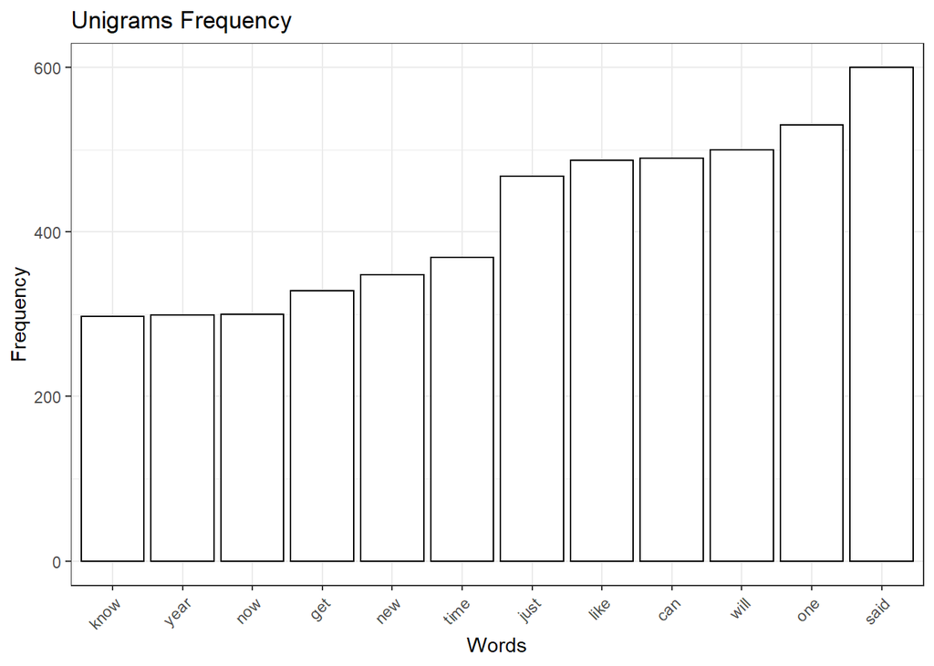

```r
oneGramToken <- NGramTokenizer(dataCorpus, Weka_control(min = 1, max = 1))
oneGram <- data.frame(table(oneGramToken))
oneGram <- oneGram[order(oneGram$Freq, decreasing = TRUE),]
colnames(oneGram) <- c("Word", "Freq")
oneGram <- head(oneGram, 12)
oneGramFreqPlot <- ggplot(oneGram, aes(x=reorder(Word, Freq),y=Freq)) +
  geom_bar(stat="identity", fill=  "white", color='black') +
  ggtitle("Unigrams Frequency") +
  xlab("Words") + ylab("Frequency") +
  theme_bw()+
  theme(axis.text.x=element_text(angle=45, hjust=1))

twoGramToken <- NGramTokenizer(dataCorpus, Weka_control(min = 2, max = 2))
twoGram <- data.frame(table(twoGramToken))
twoGram <- twoGram[order(twoGram$Freq, decreasing = TRUE),]
colnames(twoGram) <- c("Word", "Freq")
twoGram <- head(twoGram, 12)
twoGramFreqPlot <- ggplot(twoGram, aes(x=reorder(Word, Freq),y=Freq)) +
  geom_bar(stat="identity", fill=  "white", color='black') +
  ggtitle("Bigrams Frequency") +
  xlab("Words") + ylab("Frequency") +
  theme_bw()+
  theme(axis.text.x=element_text(angle=45, hjust=1))

threeGramToken <- NGramTokenizer(dataCorpus,Weka_control(min = 3, max = 3))
threeGram <- data.frame(table(threeGramToken))
threeGram <- threeGram[order(threeGram$Freq, decreasing = TRUE),]
colnames(threeGram) <- c("Word", "Freq")
threeGram <- head(threeGram, 12)
threeGramFreqPlot <- ggplot(threeGram, aes(x=reorder(Word, Freq),y=Freq)) +
  geom_bar(stat="identity", fill=  "white", color='black') +
  ggtitle("Trigrams Frequency") +
  xlab("Words") + ylab("Frequency") +
  theme_bw()+
  theme(axis.text.x=element_text(angle=45, hjust=1))
oneGramFreqPlot
```

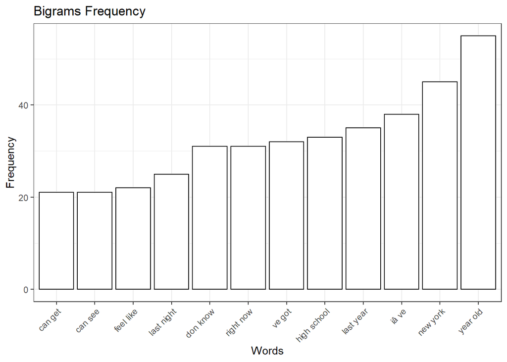

```r
twoGramFreqPlot
```

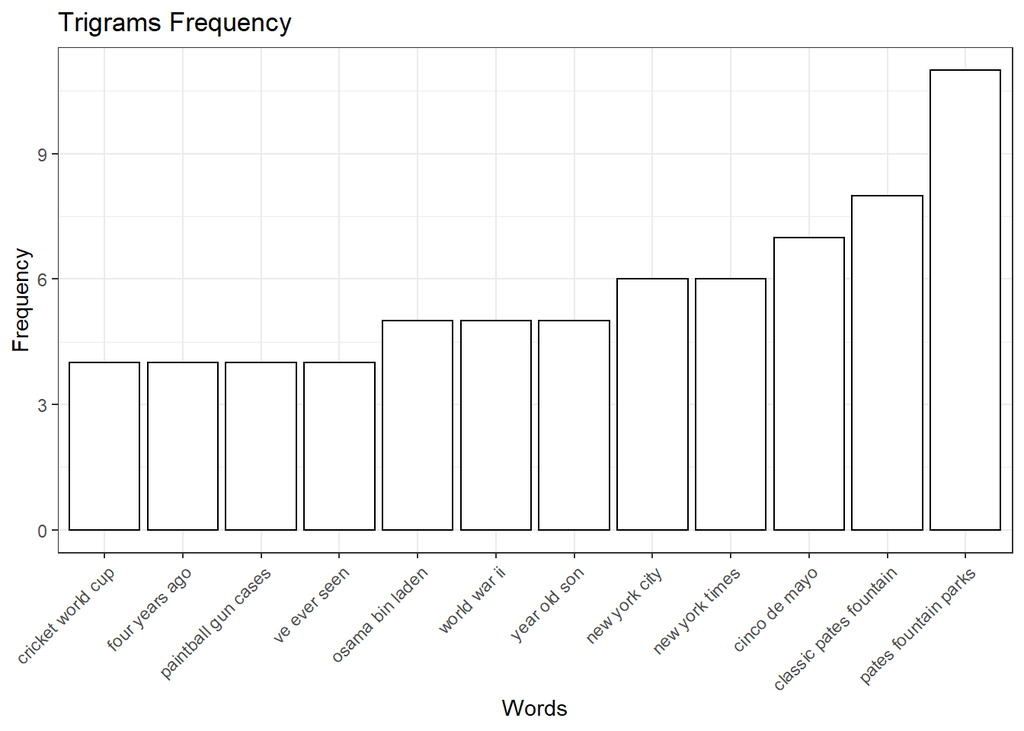

```r
threeGramFreqPlot
```

## Next Steps

After performing basic exploratory data analysis, the next steps would be to build a predictive model and to develop a shiny app.

## Appendix

The R Markdown code to generate this report can be found [here](https://github.com/pourkhesalian/CapstoneWeek2).